# Abridged Classics_Brief Summaries of Books You Were Supposed to Read but Probably Didn't.Atkinson2018

Arthur Miller

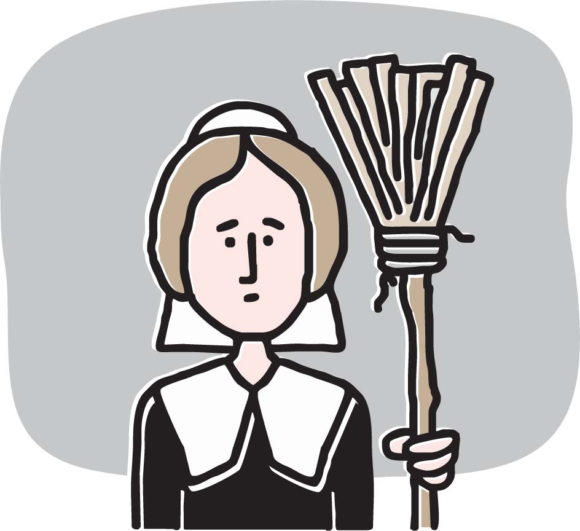

Hunt for witches turns into a witch hunt.

Ethan Frome

Edith Wharton

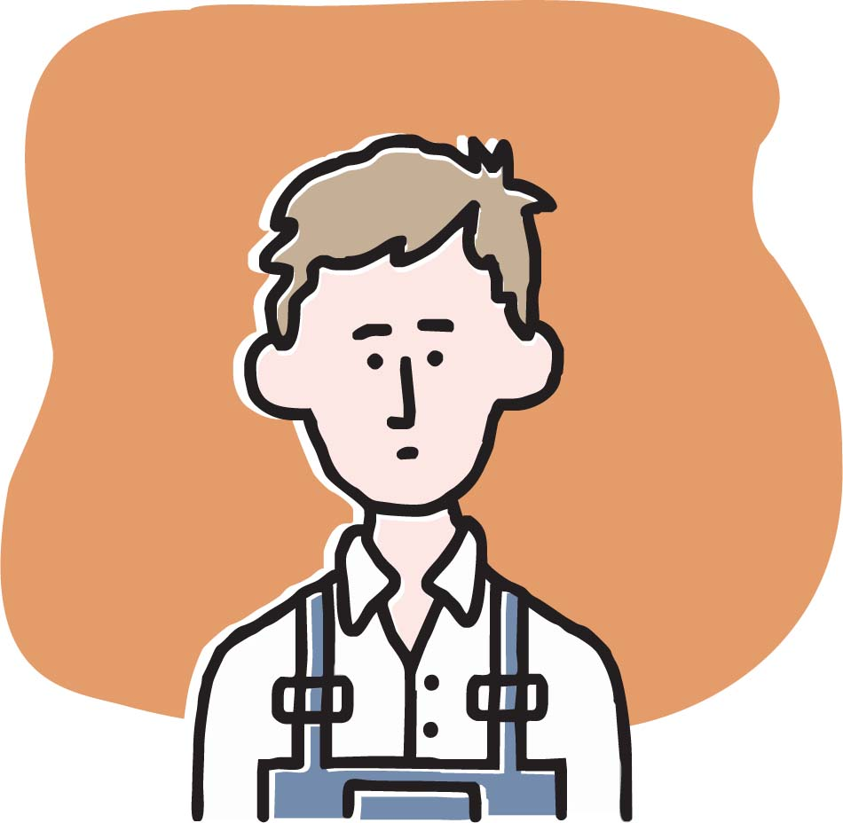

Farmer’s life can’t possibly get any worse.

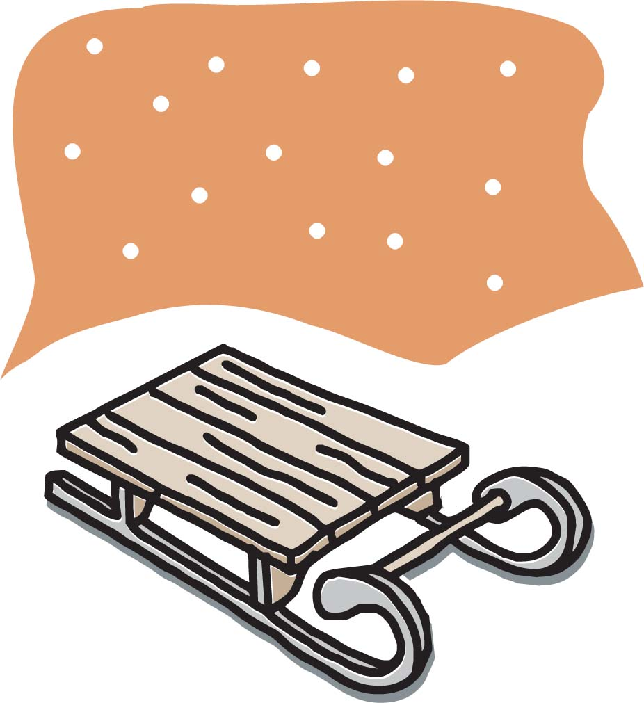

*Hey, a sled*!

Anna Karenina

Leo Tolstoy

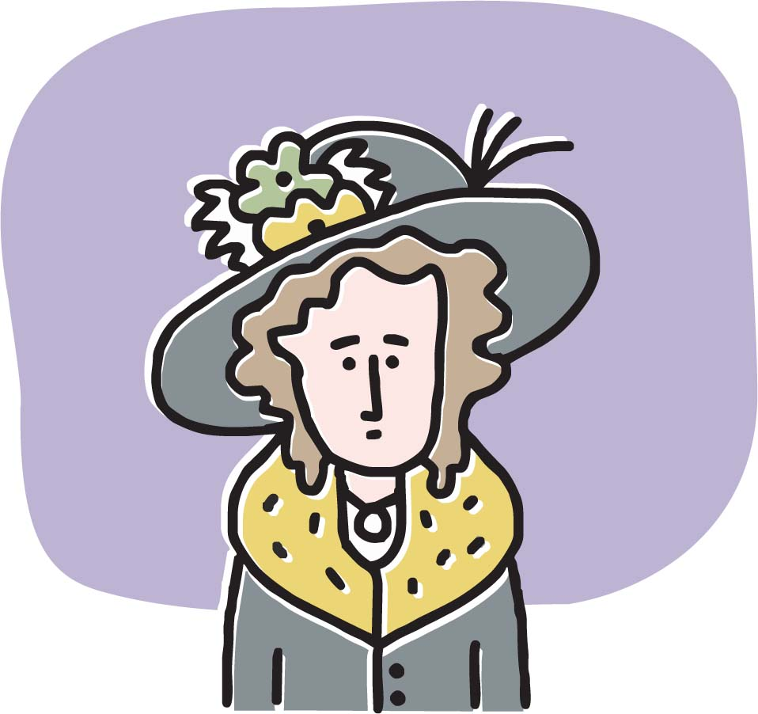

Woman has an affair.

Then it ends.

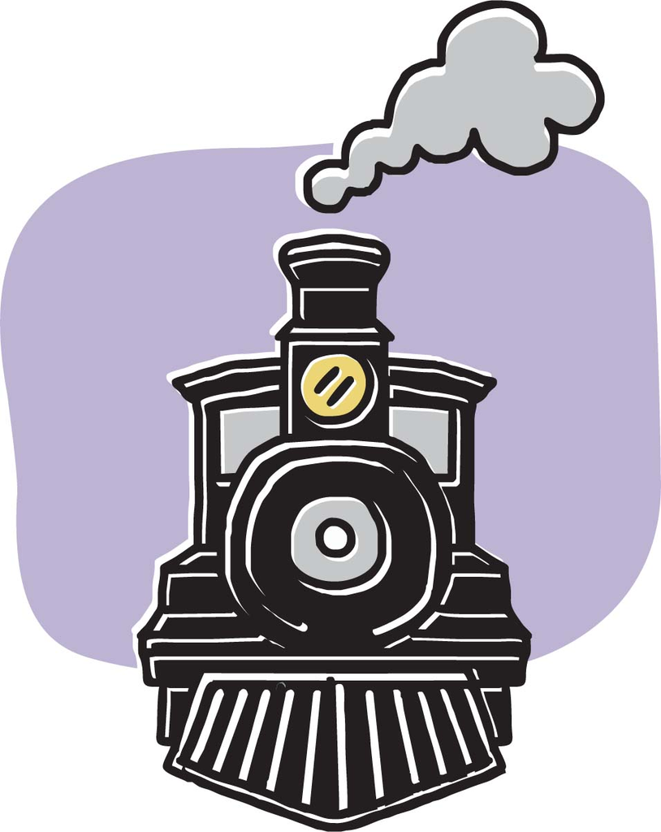

Then a train.

Jane Eyre

Charlotte Brontë

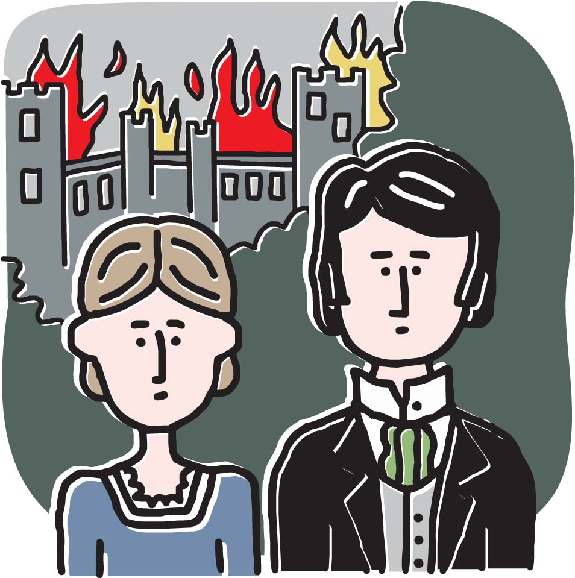

Workplace romance gets fiery.

Twelfth Night

William Shakespeare

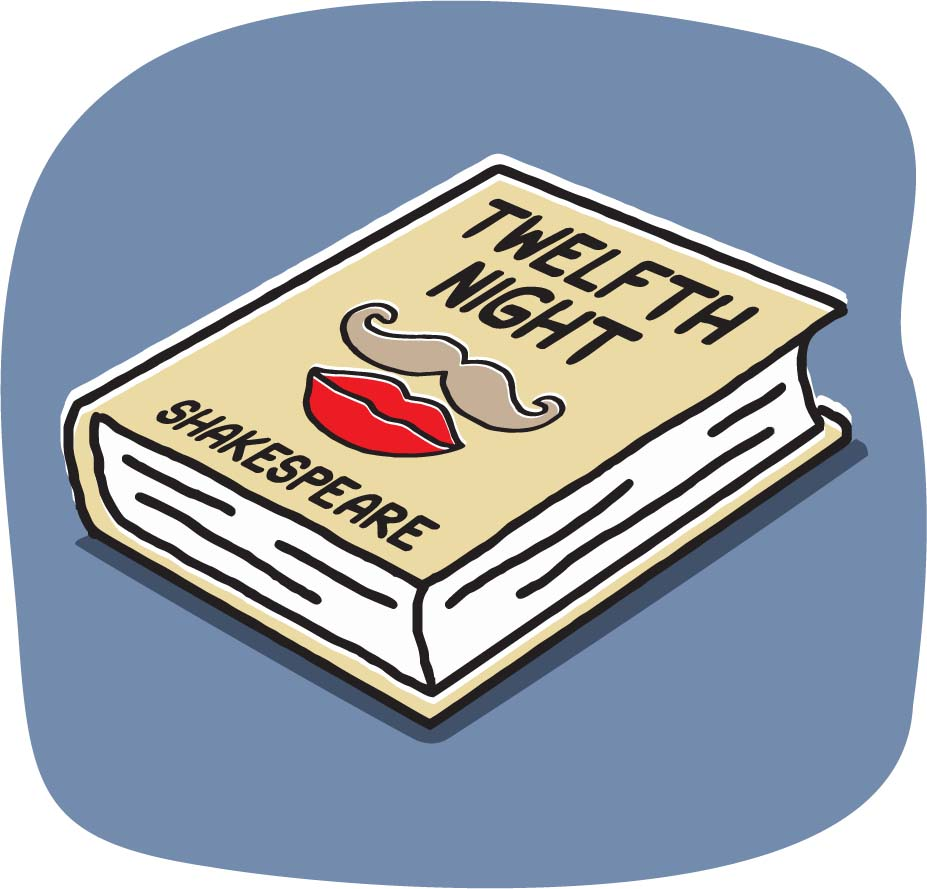

Identity theft and cross-dressing causes confusion and marriage.

The Da Vinci Code

Dan Brown

[figure not shown]

Things are hidden in art.

[figure not shown]

Jesus things.

Romeo and Juliet

William Shakespeare

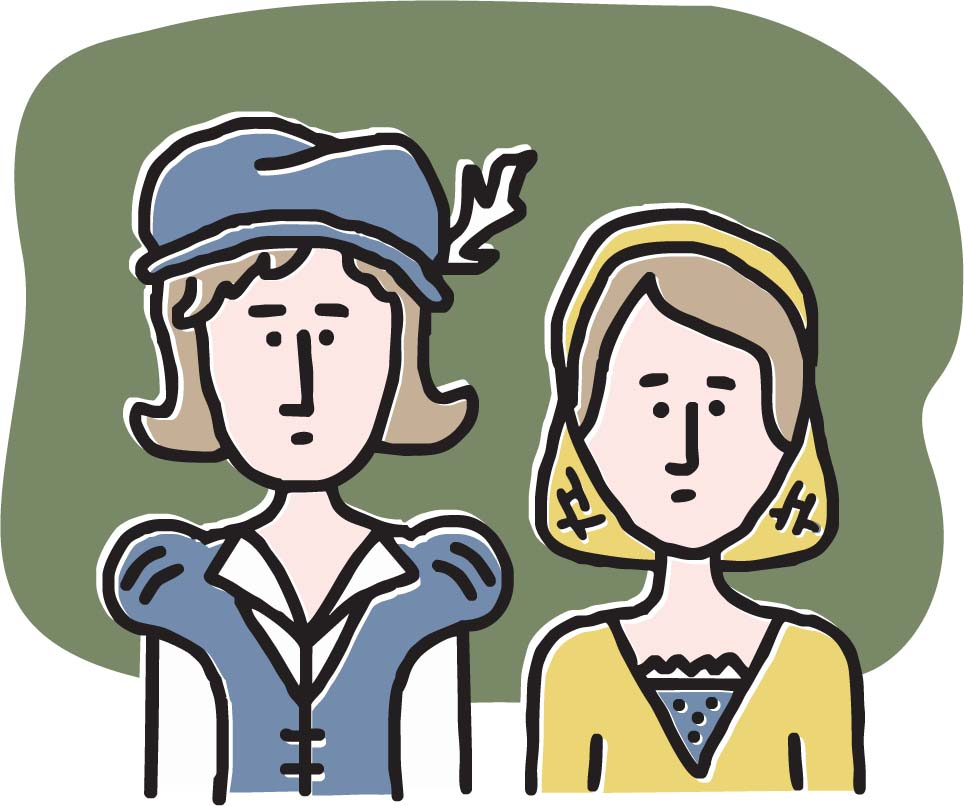

Teen lovers commit suicide.

Wait, no they don’t.

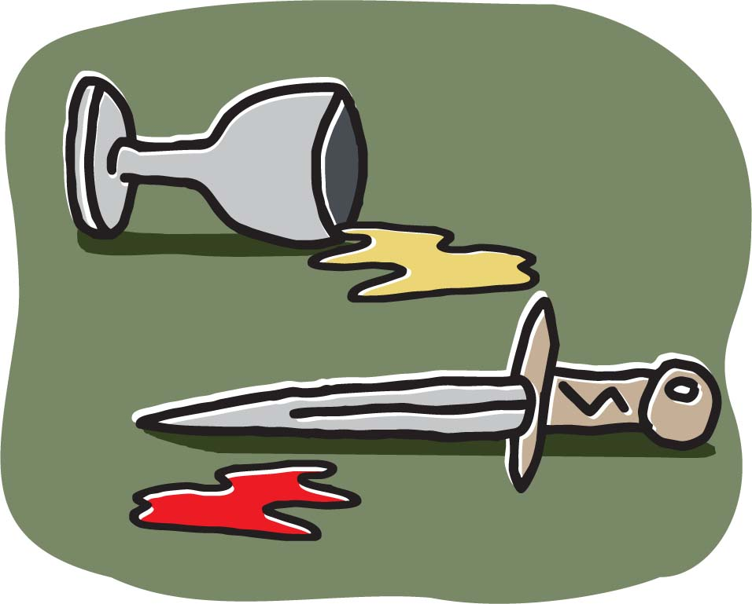

Okay, now they do.

The Mysteries of Udolpho

Ann Radcliffe

[figure not shown]

Gothic Scooby-Doo.

With lots of secret passages, fainting, and punctuation.

The Scarlet Letter

Nathaniel Hawthorne

[figure not shown]

Puritan tale of adultery, mockery, and embroidery.

Little Women

Louisa May Alcott

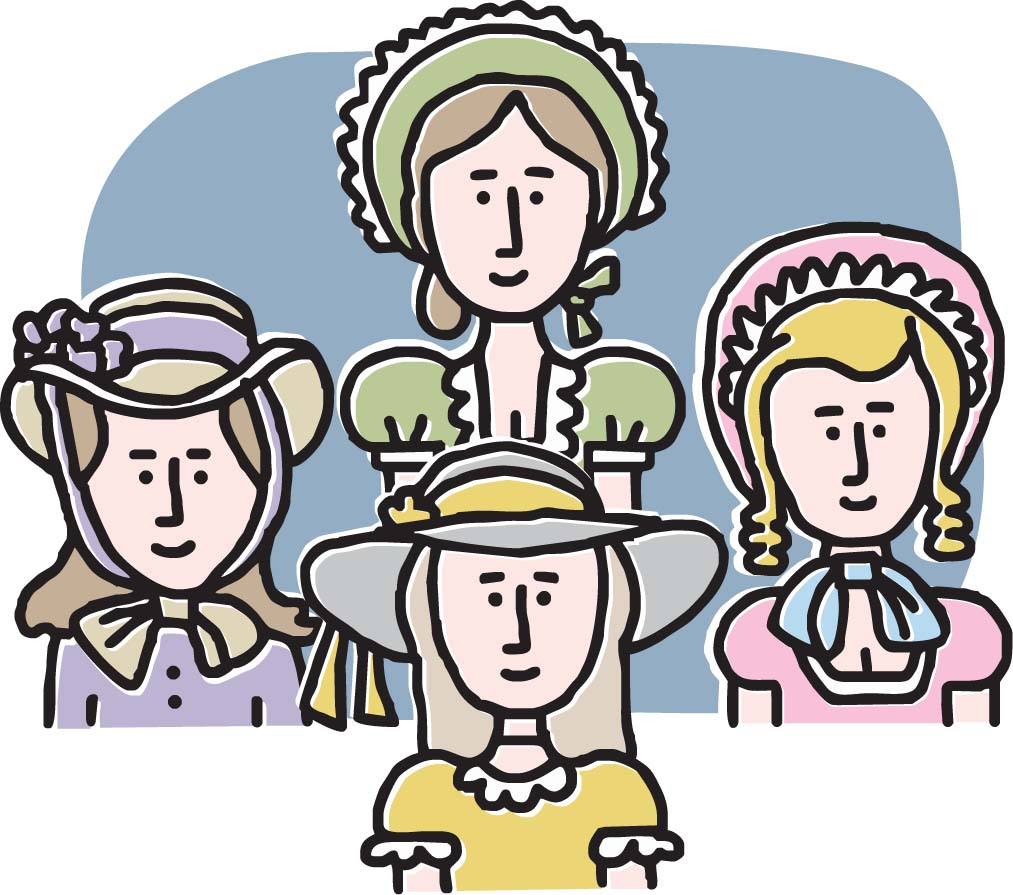

Four sisters get married.

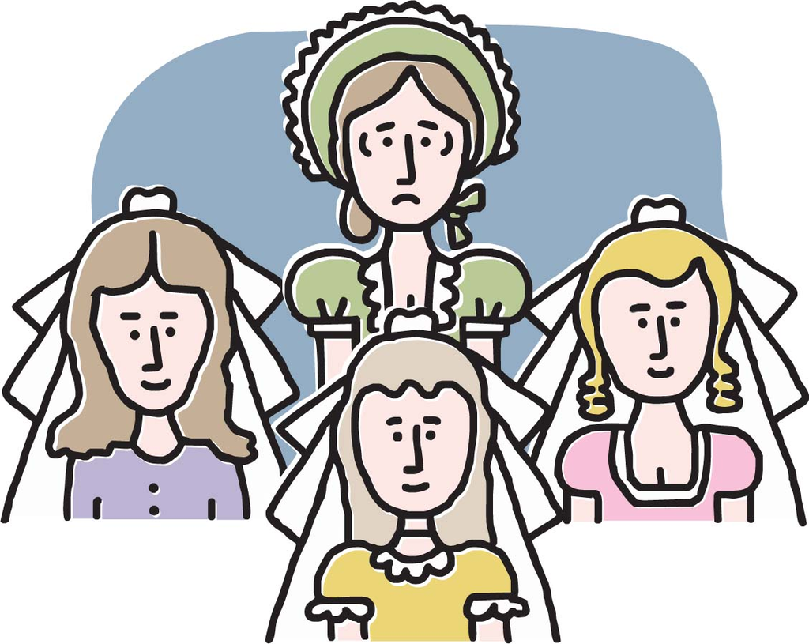

Except Beth.

The Pilgrim’s Progress

John Bunyan

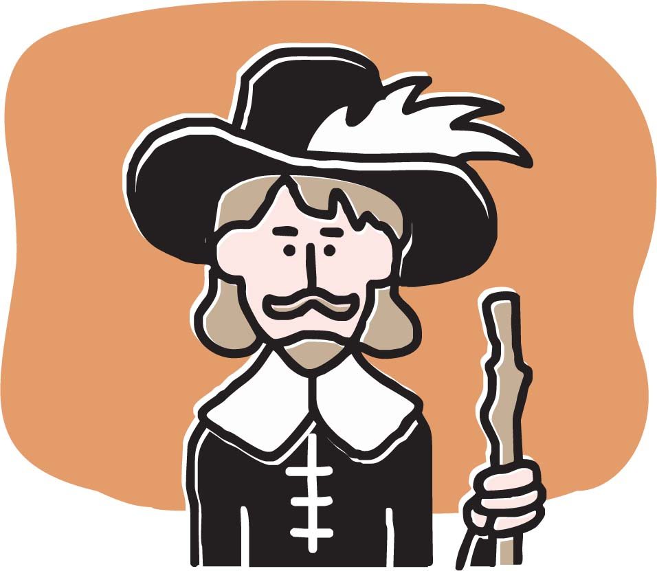

A guy named Christian walks to Heaven.

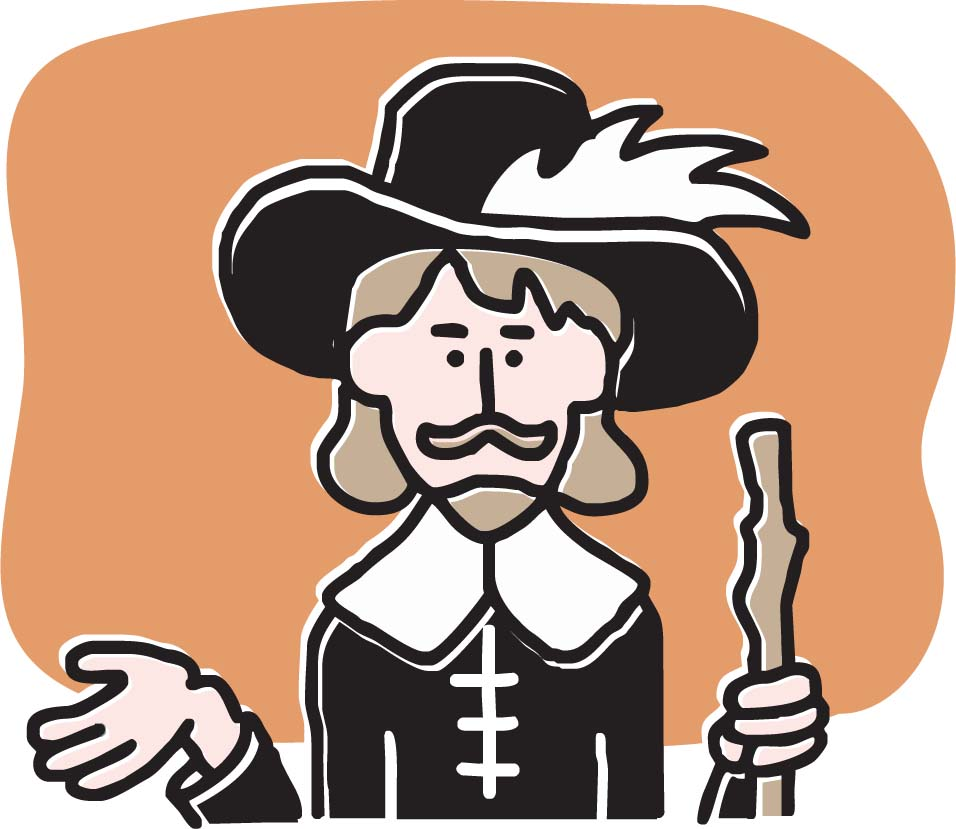

You get the idea.

Madame Bovary

Gustave Flaubert

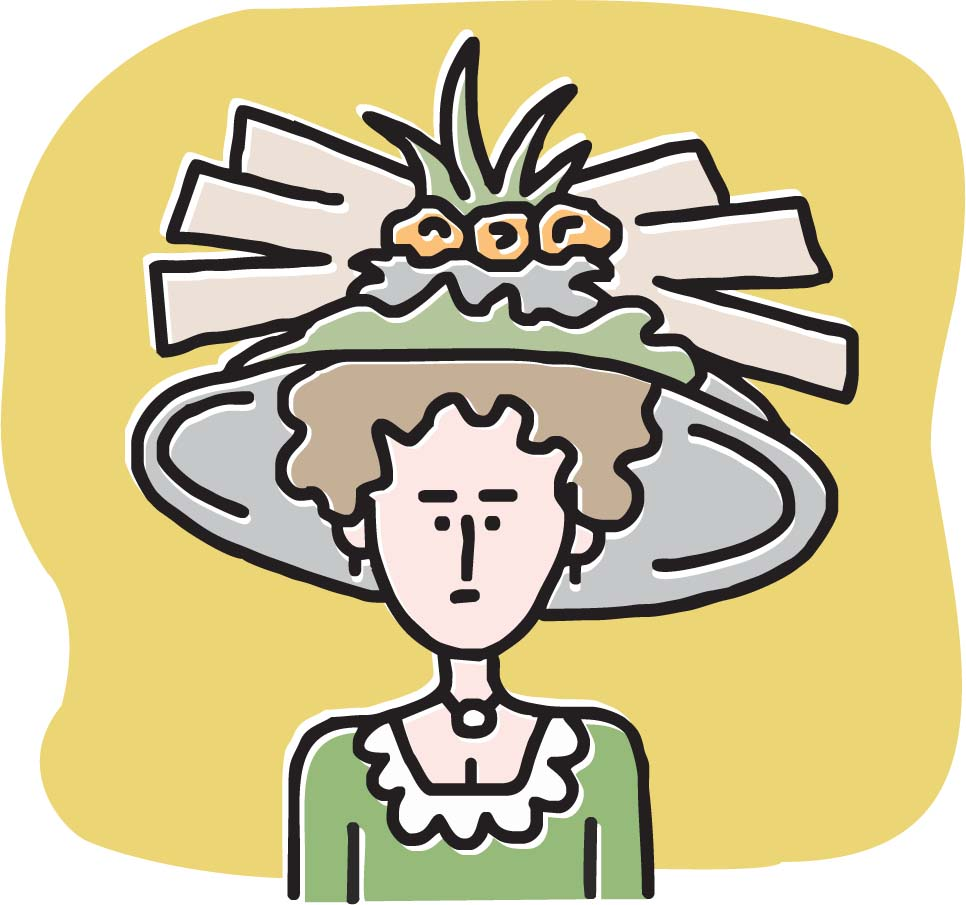

Bored woman misbehaves, then kills herself.

The Stranger

Albert Camus

[figure not shown]

Mother dies. Stranger dies.

Existentialism lives.

To the Lighthouse

Virginia Woolf

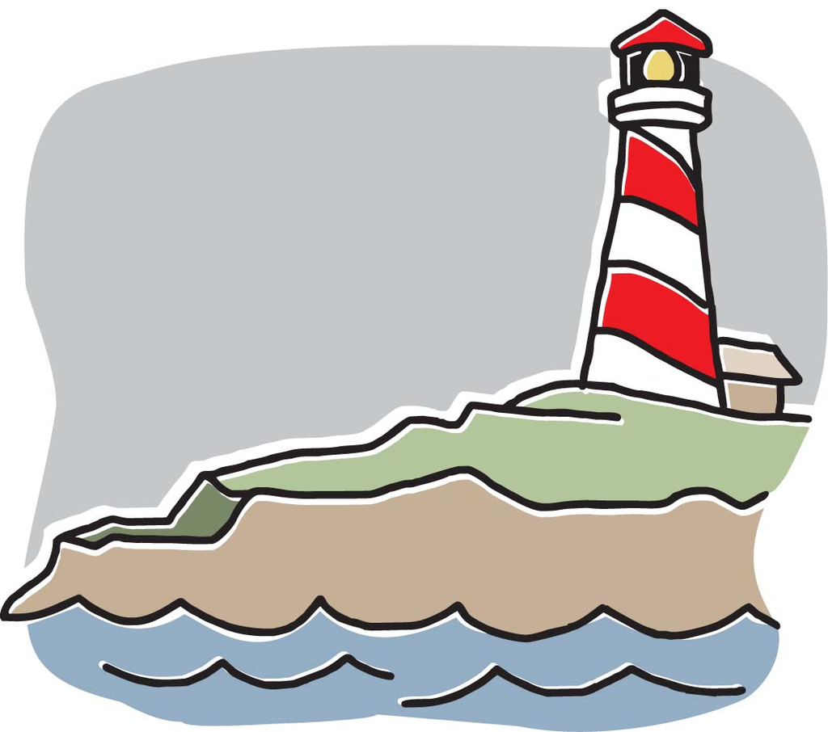

Boy wants to visit a lighthouse.

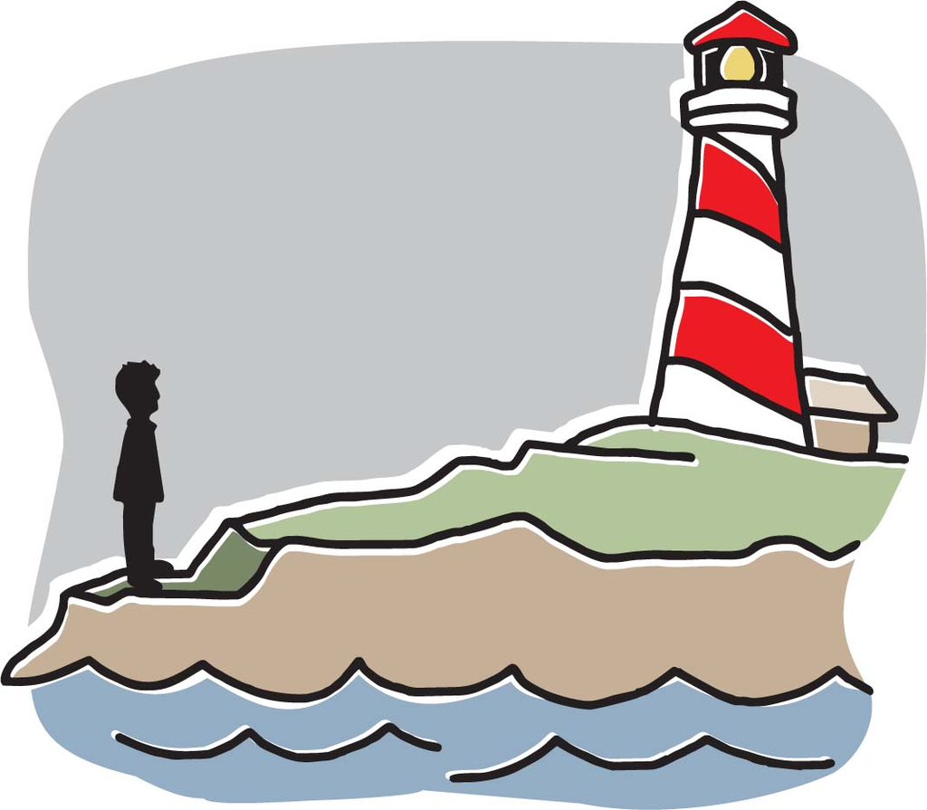

Ten years later he does.

The Metamorphosis

Franz Kafka

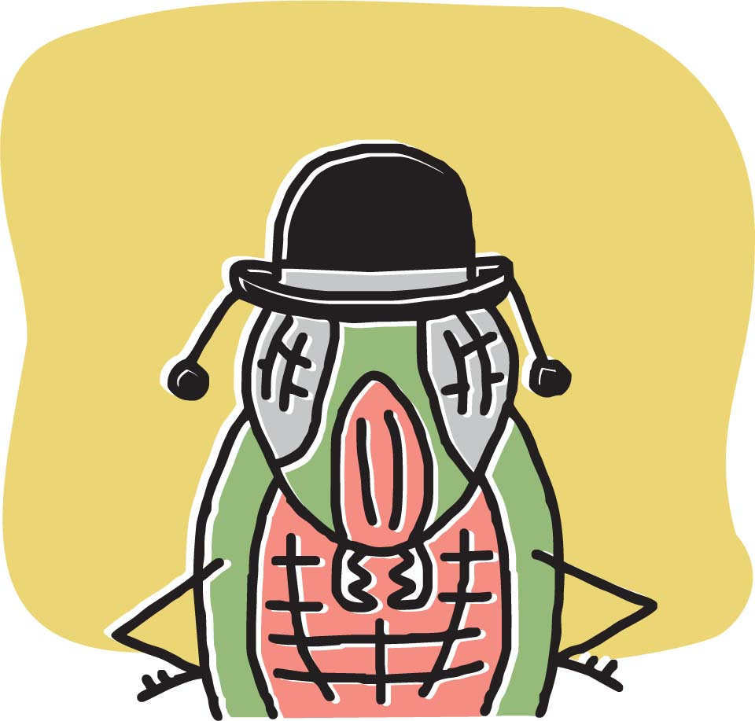

Guy becomes a giant bug.

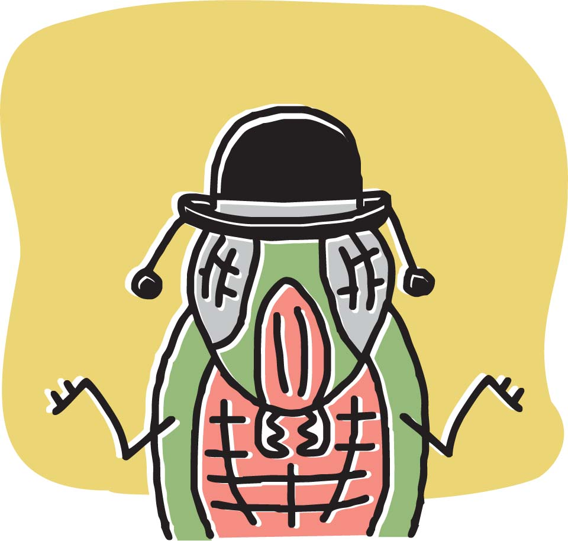

And a metaphor for something.

Waiting for Godot

Samuel Beckett

[figure not shown]

Still waiting.

Hamlet

William Shakespeare

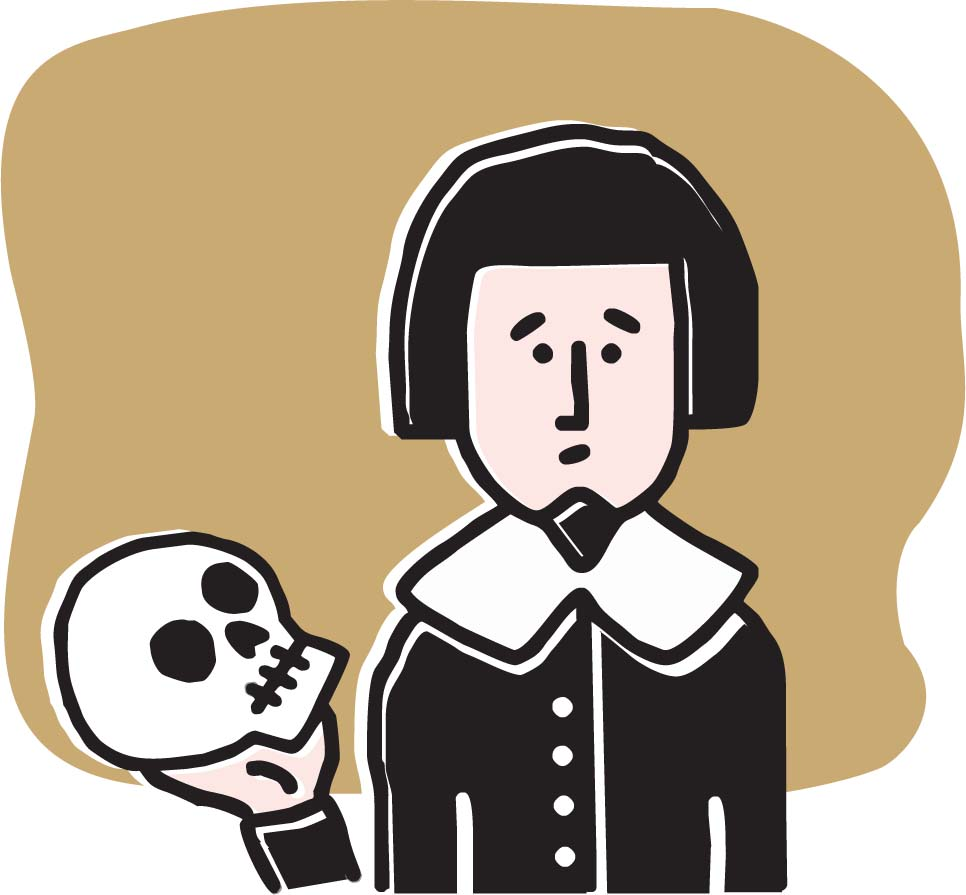

Guy with daddy issues mopes and whines about who to kill.

Of Mice and Men

John Steinbeck

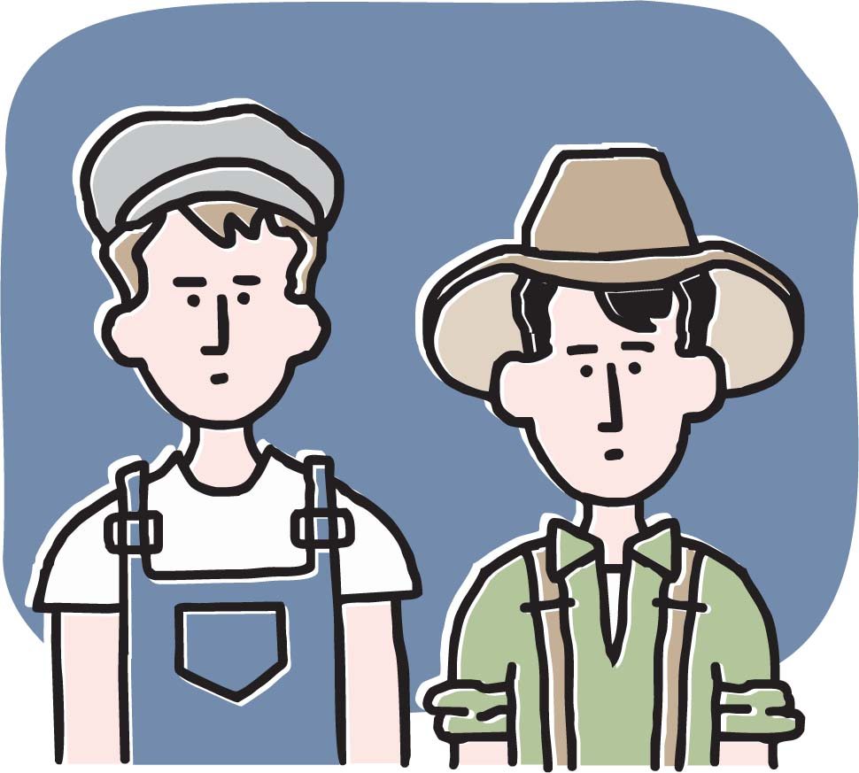

Two drifters.

Dumb one kills soft things.

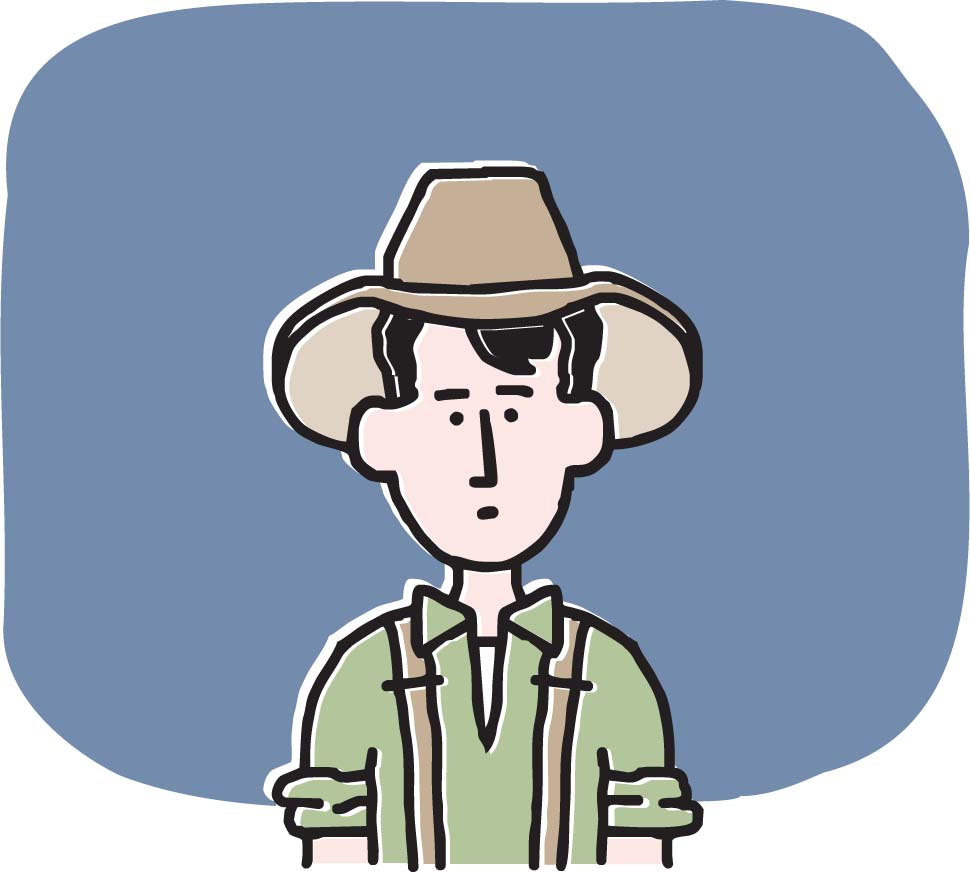

Smart one kills dumbs things.

Lolita

Vladimir Nabokov

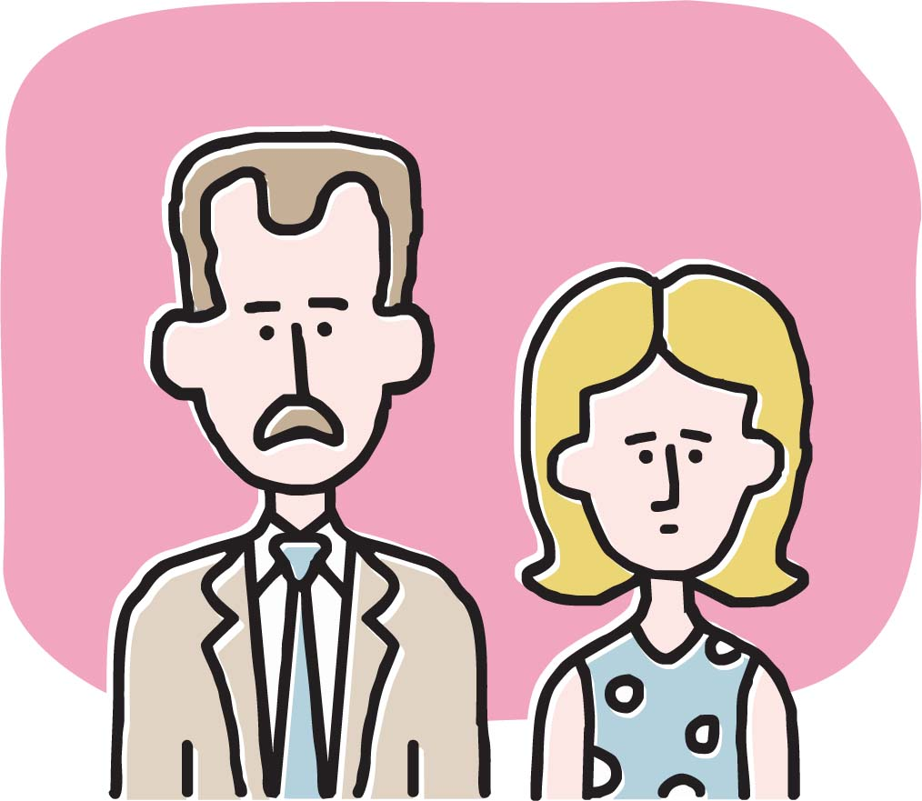

Boy meets girl.

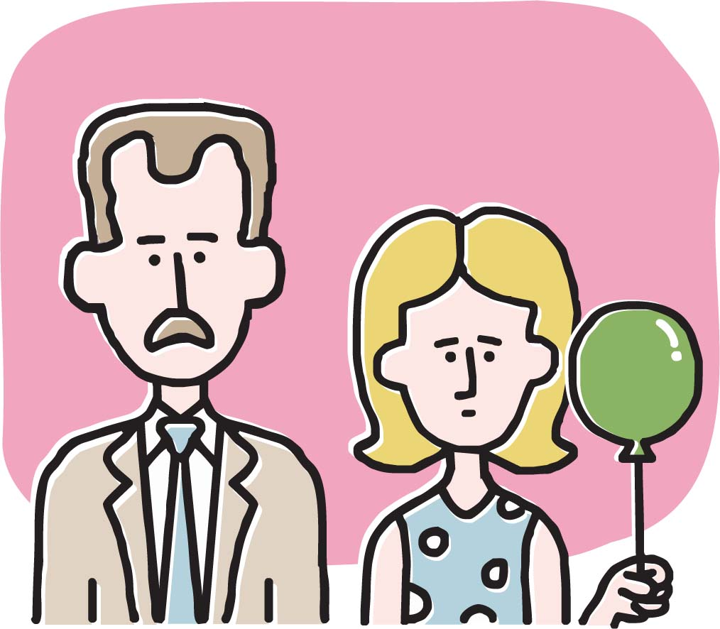

Except boy is 37 and girl is 12.

The Fountainhead

Ayn Rand

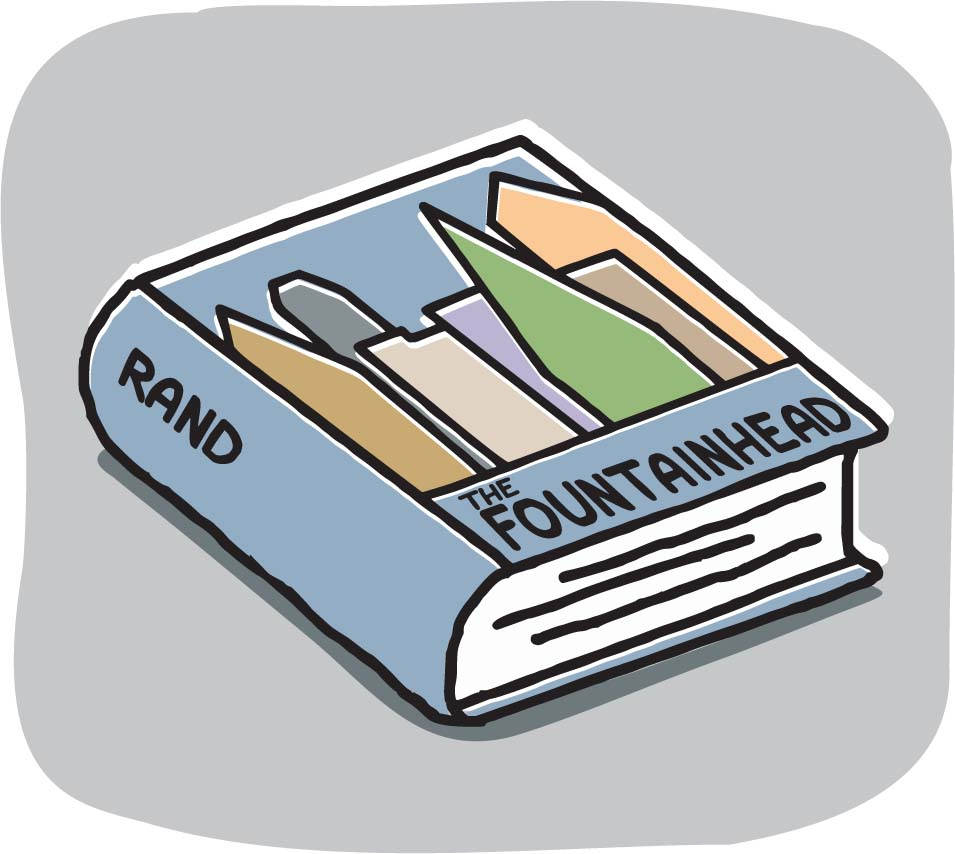

Architect-creep does whatever he wants and won’t shut up about it.

Oedipus Rex

Sophocles

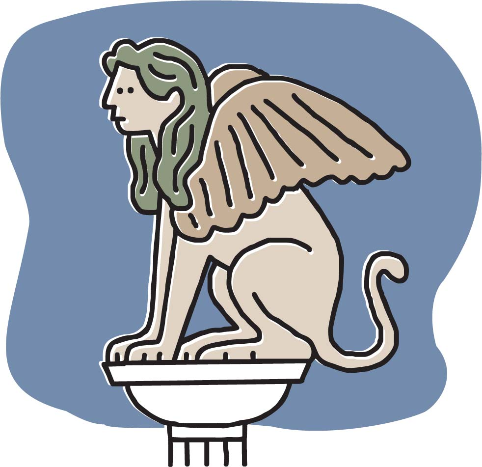

Patricide, incest, and self-mutilation: the play.

The Handmaid’s Tale

Margaret Atwood

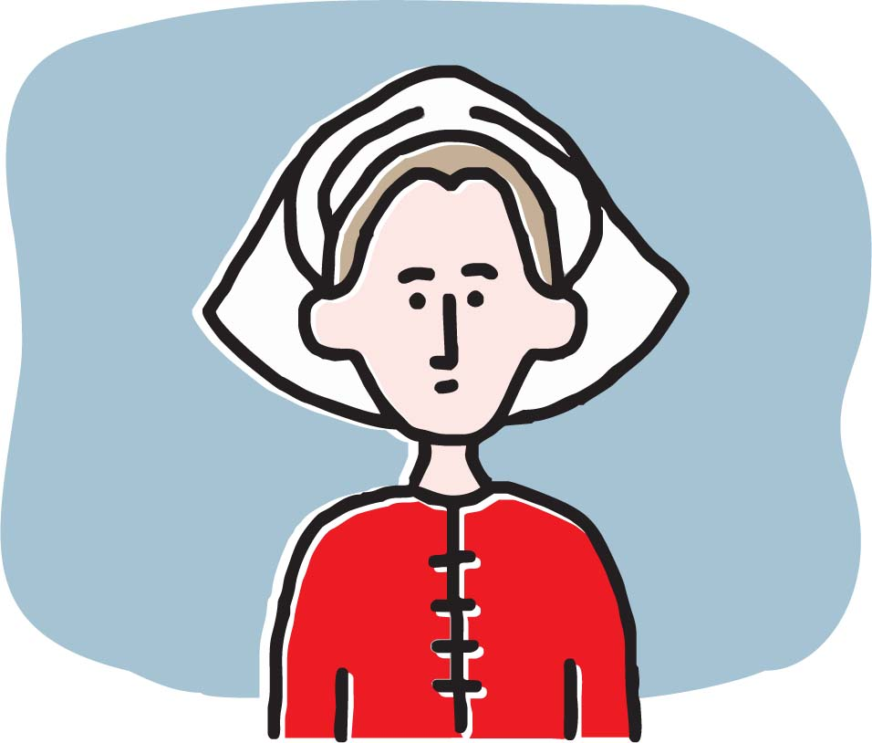

An oppressive patriarchy controls women’s bodies.

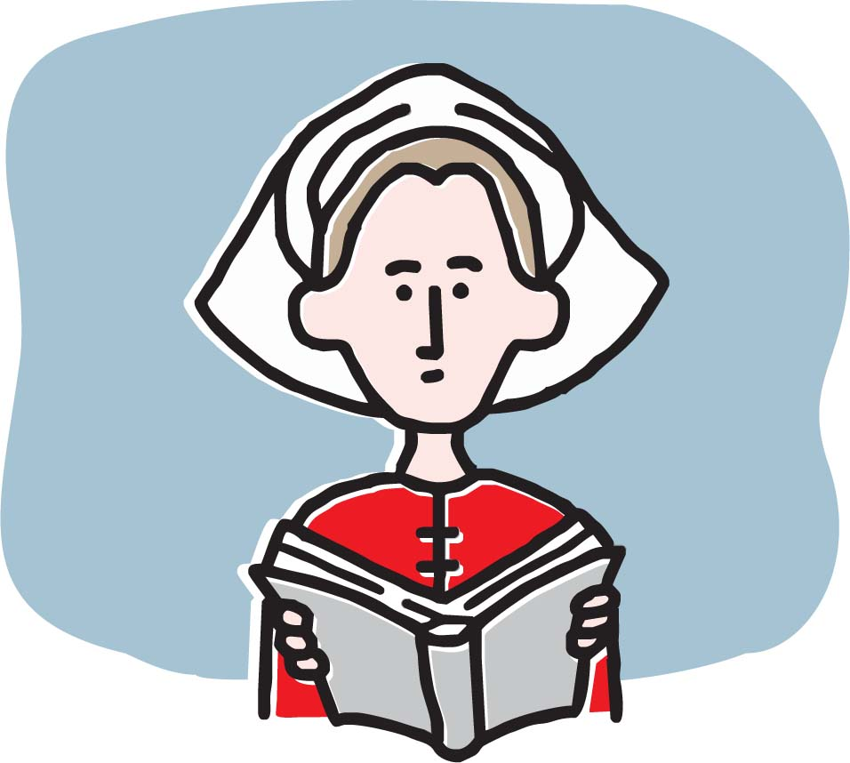

This book is also about that.

A Portrait of the Artist as a Young Man

James Joyce

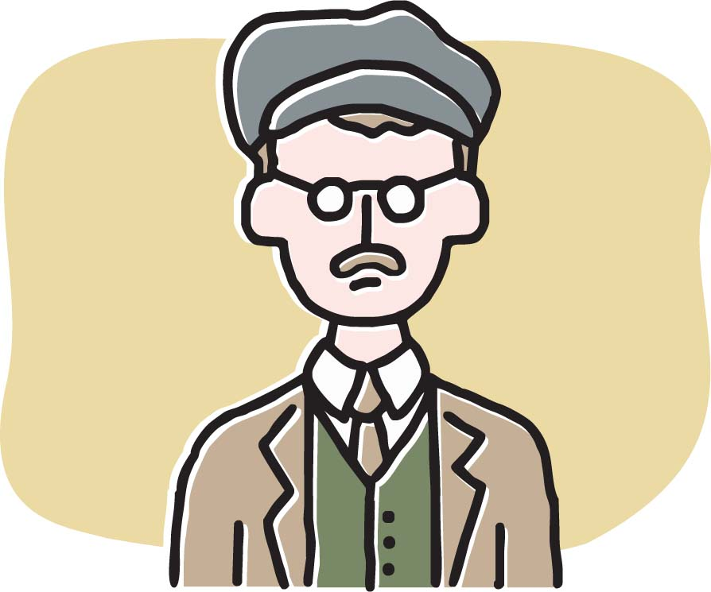

Irish lad is torn between the church and sex.

[figure not shown]

So he becomes a writer.

The Wonderful Wizard of Oz

L. Frank Baum

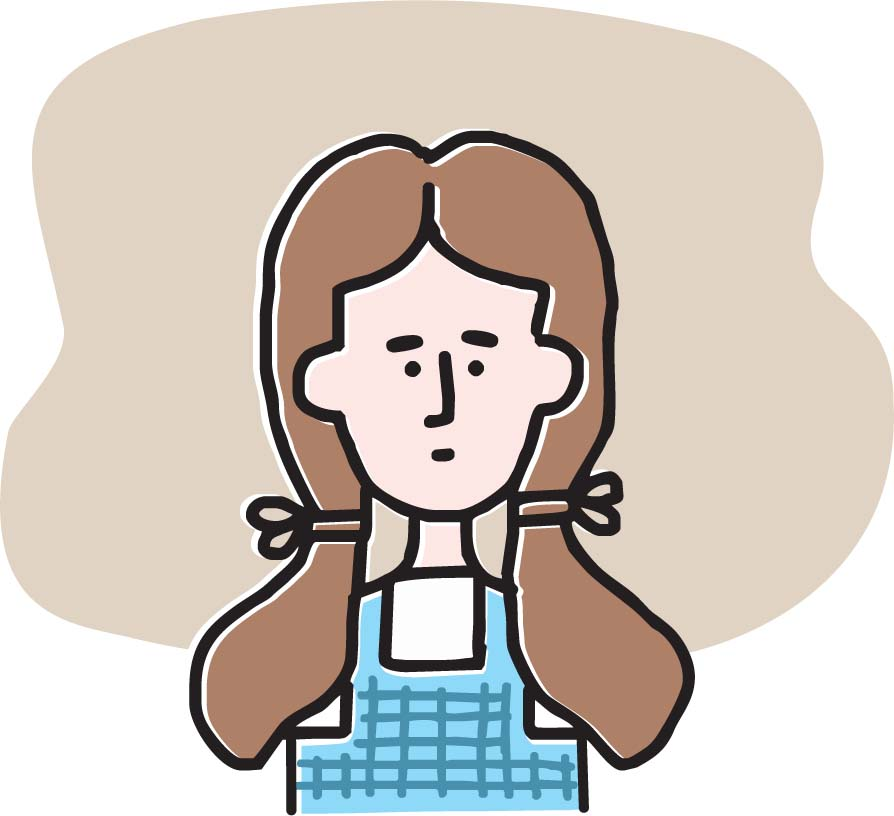

Young girl’s fanciful ordeal over footwear.

Richard III

William Shakespeare

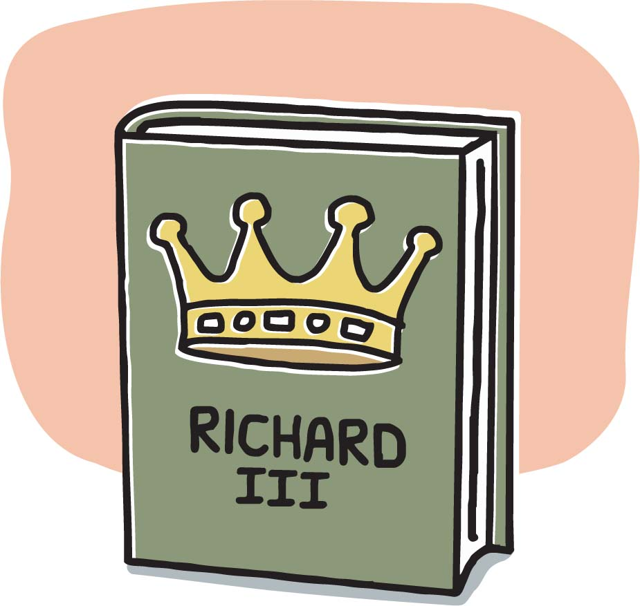

*Jerk kills everyone until he’s king* (*see also* Macbeth).

Paradise Lost

John Milton

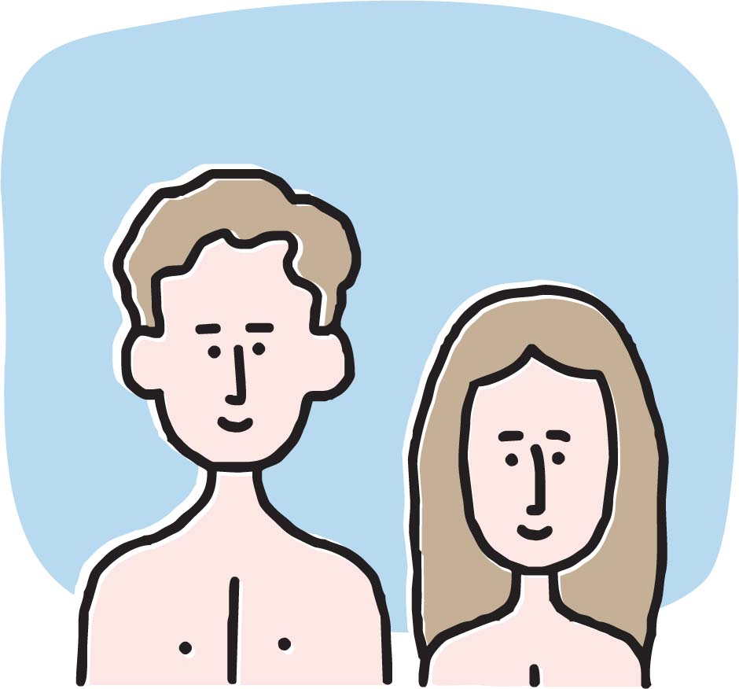

God allows free will.

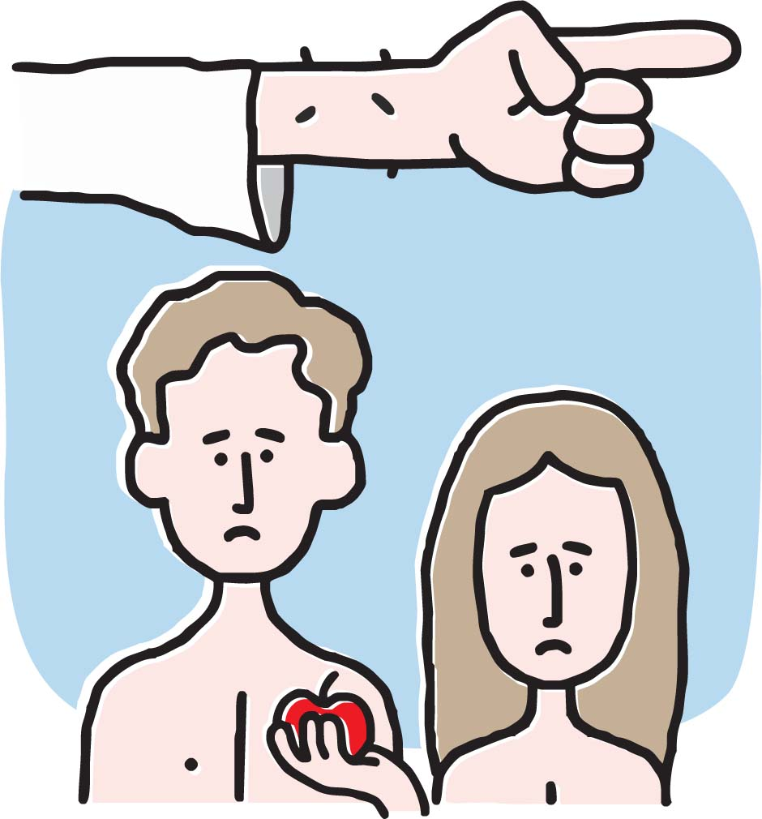

Until you mess up.

Then he banishes you.

The Lion, the Witch and the Wardrobe

C. S. Lewis

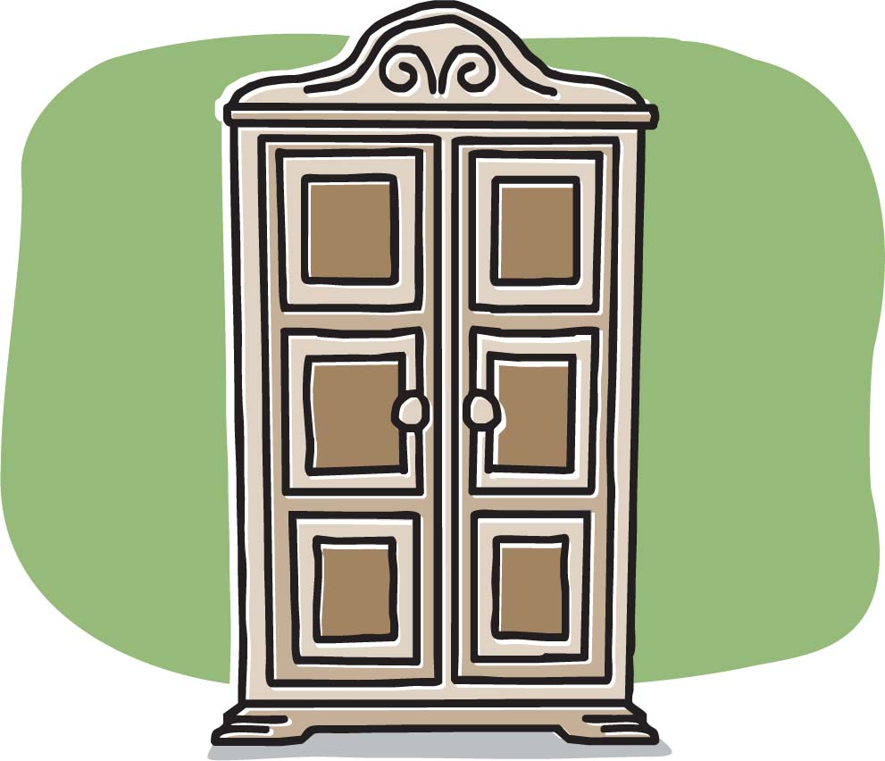

A lion eats a witch in a closet.

Some kids watch.

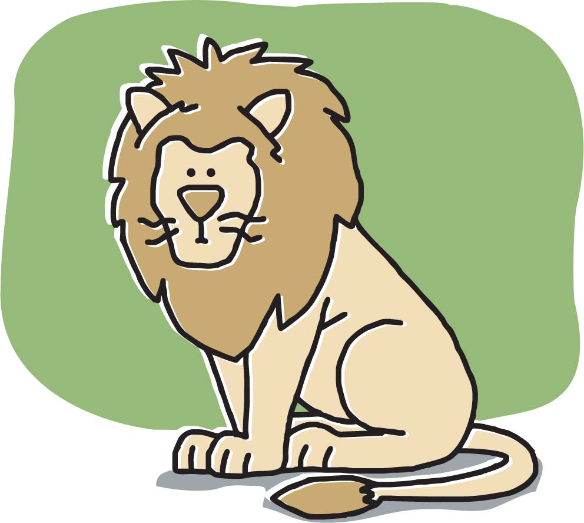

The lion is Jesus.

The Hunchback of Notre Dame

Victor Hugo

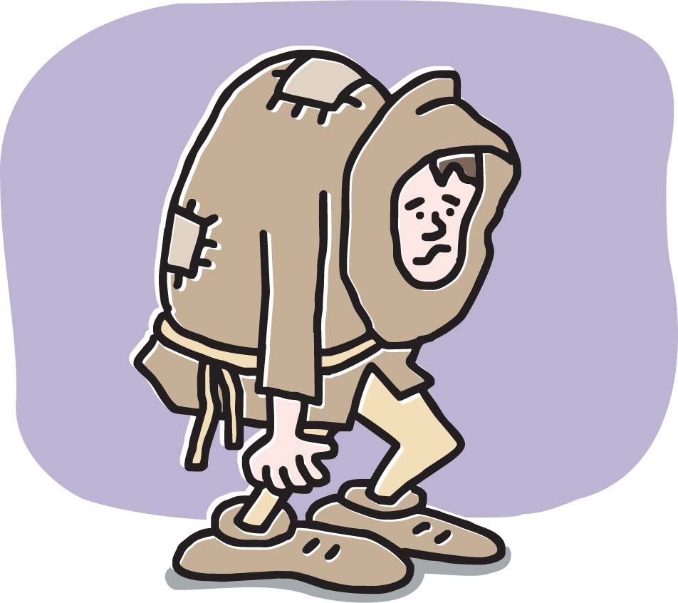

Deformed bell-ringer in a deformed society.

The Count of Monte Cristo

Alexandre Dumas

[figure not shown]

Guy escapes from jail and kills everyone who put him there.